# Intro to Mapping with GGPLOT and Rstudio

John Dreyfous

1/31/2023

**In this tutorial, I will create a map visualizing the 2021 Annual Global GDP by Country using `ggplot`. Maps are a powerful way to help visualize and interpret data. With a personal interest in GIS, this method of mapping seemed like an interesting alternative to learn in place of qGIS or ARC.**

## Step One: Install Packages and Download Data

```r
#install.packages("ggplot2")   #only do this once
#install.packages("tidyverse") #only do this once
```

To check if you have already installed these packages: `find.package(<package.name>)`

```r
library(ggplot2) # Load library with each session
library(tidyverse) # Load library with each session
worldGDP<- read.csv("GlobalGDP3.csv")

#Make sure your working directory is reading where you have saved your data file, so Rstudio can locate and upload the file properly

mapData<-map_data("world")
#View(mapData)
#View(worldGDP)
```

This GDP data was acquired from [The World Bank](https://data.worldbank.org/indicator/NY.GDP.PCAP.CD?view=chart). The World Bank has a large variety of easily accessible `.csv` data sets, which can be uploaded and used in Rstudio.

**map_data(“world”)**: data set that provides (Longitude, Latitude) for the borders of every country of the world. This data set also includes sub regions, such as the states in the USA.

In Excel, I removed unnecessary columns before uploading to Rstudio, so the uploaded `.csv` contained only **Country Name** and **2021 GDP**

## Step Two: Clean Your Data

```r
colnames(worldGDP)[1] ="region"

mapData<-left_join(mapData, worldGDP, by = "region") # Function works similarly to group_by and joins GDP into mapData by 'region' (ie. country name)
```

Column names in `mapData` and `worldGDP` must match **EXACTLY** in order for information to be grouped together correctly. Rows names must also match **EXACTLY**.

If GDP information data does not populate a country when mapped, double check that the column(‘region’) names are the same.

## Step Three: Make and Customize Your Map

```r
map1<-ggplot(mapData, mapping=aes(x= long, y=lat, group=group)) + geom_polygon(aes(fill= GDP), color="black")
```

`map1` creates a basic map visualizing the 2021 Annual GDP by country. It uses a default color gradient and fills the **borders** of countries with color=“black”

```r
# install.packages("viridis")
# install.packages("RColorBrewer") # only have to do this once
library(viridis)
library(RColorBrewer)
```

Once you have loaded your library with the necessary color palettes, `scale_fill_viridis()` allows you to select a color spectrum.

Feel free to experiment with the color spectrum that best suits your data set

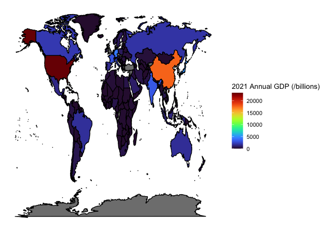

```r
map2 <- map1 + scale_fill_viridis(name="2021 Annual GDP (/billions)", option="turbo")+
  theme(axis.text.x = element_blank(), # removes X-axis text
        axis.text.y = element_blank(), # removes y-axis text
        axis.ticks = element_blank(), # removes x-axis grid line
        axis.title.y=element_blank(), # removes y-axis title
        axis.title.x=element_blank(), # removes x-axis title
        rect = element_blank())
map2
```

To view all available schemes in **RColorBrewer**: `display.brewer.all()`

**Color Blind Friendly**: `display.brewer.all(colorblindFriendly=TRUE)`

**Sequential Gradients**: `display.brewer.all(type="seq")`

If you have made it this far, you have successfully replicated a map using `ggplot`.

This is one of many tools available to map in Rstudio. To use Google Maps generated maps, you can use `ggmaps()` and the `Leaflet` packages. Alternatively, maps can be downloaded for use in Rstudio from [OpenStreetMap](https://www.openstreetmap.org/#map=4/38.01/-95.84).

### Video Tutorial:

For an in depth video tutorial of the methods described above click: [HERE](https://lvash.github.io/BIOL1007A/Final-Assignment-Guidelines.html)